# INDEX

# 1. Load Libraries

```r
library(dplyr)
library(ggplot2)
library(corrplot)
library(stringr)
library(caret)
library(reshape2)
```

# 2. Reading train file

```r
#Read application_train.csv file
app_train <- read.csv("application_train.csv")
```

# 3. Viewing data

```r
#View structure and summary of data
str(app_train)
```

```
## 'data.frame':    307511 obs. of  122 variables:
##  $ SK_ID_CURR                  : int  100002 100003 100004 100006 100007 100008 100009 100010 100011 100012 ...
##  $ TARGET                      : int  1 0 0 0 0 0 0 0 0 0 ...
##  $ NAME_CONTRACT_TYPE          : chr  "Cash loans" "Cash loans" "Revolving loans" "Cash loans" ...
##  $ CODE_GENDER                 : chr  "M" "F" "M" "F" ...
##  $ FLAG_OWN_CAR                : chr  "N" "N" "Y" "N" ...
##  $ FLAG_OWN_REALTY             : chr  "Y" "N" "Y" "Y" ...
##  $ CNT_CHILDREN                : int  0 0 0 0 0 0 1 0 0 0 ...
##  $ AMT_INCOME_TOTAL            : num  202500 270000 67500 135000 121500 ...
##  $ AMT_CREDIT                  : num  406598 1293503 135000 312683 513000 ...
##  $ AMT_ANNUITY                 : num  24701 35699 6750 29687 21866 ...
##  $ AMT_GOODS_PRICE             : num  351000 1129500 135000 297000 513000 ...
##  $ NAME_TYPE_SUITE             : chr  "Unaccompanied" "Family" "Unaccompanied" "Unaccompanied" ...
##  $ NAME_INCOME_TYPE            : chr  "Working" "State servant" "Working" "Working" ...
##  $ NAME_EDUCATION_TYPE         : chr  "Secondary / secondary special" "Higher education" "Secondary / secondary special" "Secondary / secondary special" ...
```

[output cut: 86 more lines]

```r
summary(app_train$TARGET)
```

```
##    Min. 1st Qu.  Median    Mean 3rd Qu.    Max.
## 0.00000 0.00000 0.00000 0.08073 0.00000 1.00000
```

## There are 307511 rows and 122 features including TARGET variable.The target is categorical variable classified as “0” for the loan was repaid on time with no difficulties and “1” indicating the client had payment difficulties.

# 4. Missing Value check

```r
#Checking missing value in target variable
missing_count <- sum(is.na(app_train$TARGET))
missing_count
```

```
## [1] 0
```

## There are no missing values in Target variable

# 5. Check count distribution of target variable

```r
# View count of clients in each class
table(app_train$TARGET)
```

```
##
##      0      1
## 282686  24825
```

## Here 24825 clients are observed to have payment difficulties, whereas 282686 people have no payment difficulties.

# 6. Visualize count distribution of target variable

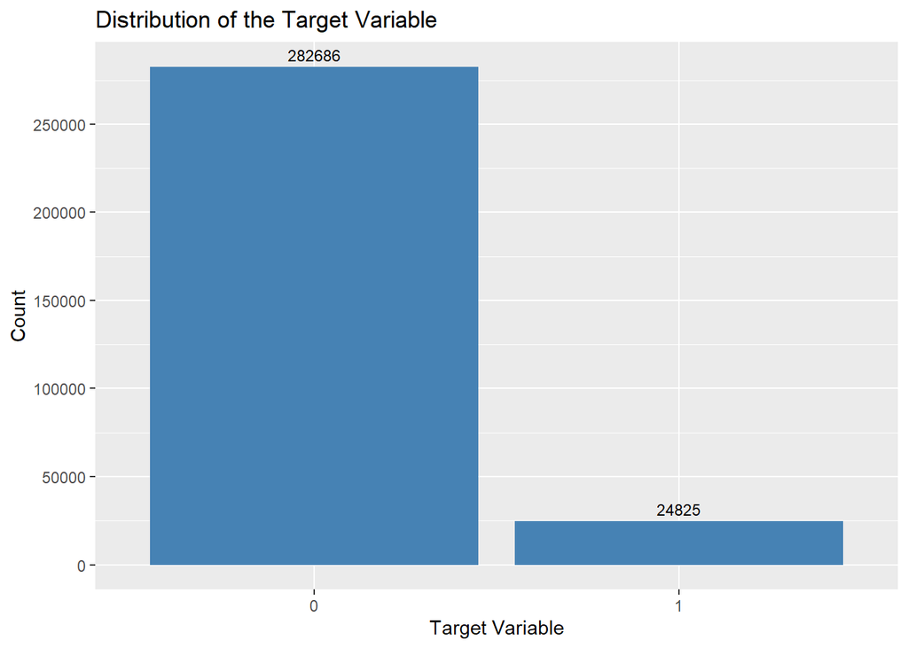

```r
library(ggplot2)
ggplot(app_train, aes(x = as.factor(TARGET))) +
  geom_bar(fill = "steelblue") +
  geom_text(stat = "count", aes(label = ..count..), vjust = -0.5, color = "black", size = 3) +
  labs(x = "Target Variable", y = "Count") +
  ggtitle("Distribution of the Target Variable") +
  scale_y_continuous(breaks = seq(0, max(table(app_train$TARGET)), by = 50000))
```

## Above Target variable distribution shows that majority clients come under no payment difficulties class(0), only 24825 clients have payment difficulties.

```r
# View the proportion of target variable
proportion <- prop.table(table(app_train$TARGET)) * 100
proportion
```

```
##
##         0         1
## 91.927118  8.072882
```

## 91.92% of the clients are observed to have no payment difficulties, 8.07% clients face payment difficulties.The data looks unbalaced with respect target variable as proportion for class 0 is much higher (91.92%) than that of class 1 (8.07%)

# 7. Visualize the proportion of target variable

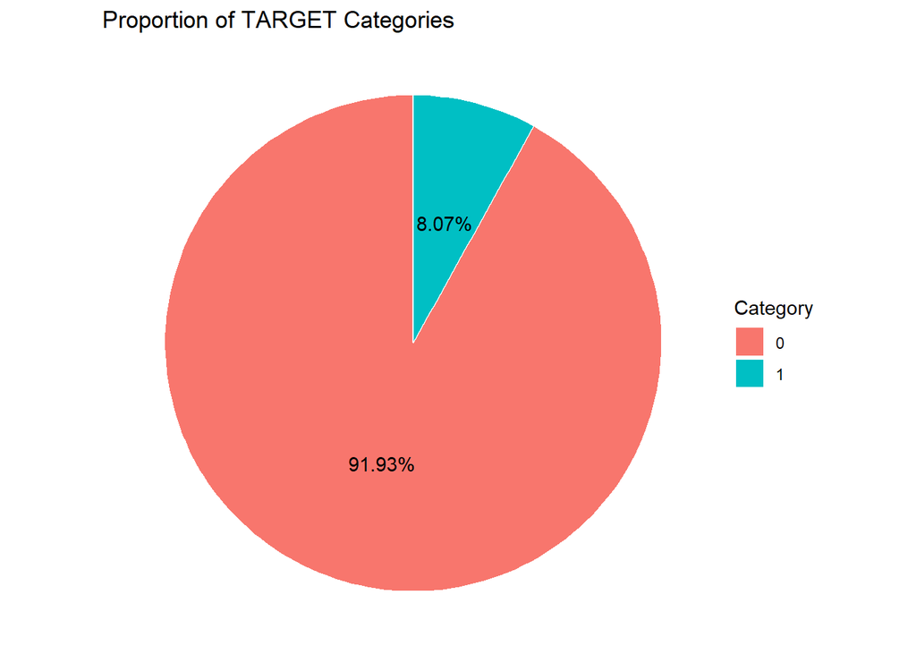

```r
# Calculate the proportion and convert it to percentages
proportion <- prop.table(table(app_train$TARGET)) * 100

# Create a data frame for plotting
pie_data <- data.frame(category = names(proportion), proportion = proportion)

# Create the pie chart using ggplot
pie_chart <- ggplot(pie_data, aes(x = "", y = proportion, fill = category)) +
  geom_bar(stat = "identity", width = 1, color = "white") +
  coord_polar("y", start = 0) +
  theme_void() +
  labs(fill = "Category") +
  geom_text(aes(label = paste0(round(proportion, 2), "%")), position = position_stack(vjust = 0.5)) +
  labs(title = "Proportion of TARGET Categories")

# Display the pie chart
print(pie_chart)
```

# 8. Determine accuracy for majority class classifier

```r
# Count of majority class
majority_count <- max(table(app_train$TARGET))

# Total number of clients in the target class
total_count <- length(app_train$TARGET)

# Accuracy for majority class
accuracy <- majority_count / total_count

accuracy
```

```
## [1] 0.9192712
```

## The accuracy for majority class classifier “0” (client with no payment difficulties) is 91.92% which is same as the proportion of class “0” clients in the data.

# 9. Correlation of Target and Numeric Predictors

```r
#Getting list of Top5 positive and top 5 negative predictors

# Separate numeric predictors
numeric_vars <- app_train %>%
                select_if(is.numeric)

# Calculate correlation between numeric predictors and target variable
cor_target <- cor(numeric_vars, numeric_vars$TARGET, use = "pairwise.complete.obs", method = "pearson")
cor_target
```

```
##                                       [,1]
## SK_ID_CURR                   -0.0021084690
## TARGET                        1.0000000000
## CNT_CHILDREN                  0.0191871336
## AMT_INCOME_TOTAL             -0.0039818656
## AMT_CREDIT                   -0.0303692865
## AMT_ANNUITY                  -0.0128165615
## AMT_GOODS_PRICE              -0.0396452812
## REGION_POPULATION_RELATIVE   -0.0372271485
## DAYS_BIRTH                    0.0782393083
## DAYS_EMPLOYED                -0.0449316627
## DAYS_REGISTRATION             0.0419748628
## DAYS_ID_PUBLISH               0.0514571726
## OWN_CAR_AGE                   0.0376115643
## FLAG_MOBIL                    0.0005343956
## FLAG_EMP_PHONE                0.0459822197
## FLAG_WORK_PHONE               0.0285243224
## FLAG_CONT_MOBILE              0.0003701268
## FLAG_PHONE                   -0.0238062723
## FLAG_EMAIL                   -0.0017583834
## CNT_FAM_MEMBERS               0.0093077844
## REGION_RATING_CLIENT          0.0588990149
## REGION_RATING_CLIENT_W_CITY   0.0608926676
## HOUR_APPR_PROCESS_START      -0.0241658314
## REG_REGION_NOT_LIVE_REGION    0.0055759445
## REG_REGION_NOT_WORK_REGION    0.0069419075
## LIVE_REGION_NOT_WORK_REGION   0.0028194792
## REG_CITY_NOT_LIVE_CITY        0.0443953748
## REG_CITY_NOT_WORK_CITY        0.0509944644
## LIVE_CITY_NOT_WORK_CITY       0.0325183411
## EXT_SOURCE_1                 -0.1553171261
## EXT_SOURCE_2                 -0.1604716716
## EXT_SOURCE_3                 -0.1789186976
## APARTMENTS_AVG               -0.0294975646
## BASEMENTAREA_AVG             -0.0227457432
## YEARS_BEGINEXPLUATATION_AVG  -0.0097276733
## YEARS_BUILD_AVG              -0.0221492841
## COMMONAREA_AVG               -0.0185496616
## ELEVATORS_AVG                -0.0341987937
## ENTRANCES_AVG                -0.0191721820
```

[output cut: 52 more lines]

```
## FLAG_DOCUMENT_13             -0.0115832223
## FLAG_DOCUMENT_14             -0.0094638219
## FLAG_DOCUMENT_15             -0.0065356576
## FLAG_DOCUMENT_16             -0.0116146716
## FLAG_DOCUMENT_17             -0.0033775691
## FLAG_DOCUMENT_18             -0.0079523851
## FLAG_DOCUMENT_19             -0.0013575183
## FLAG_DOCUMENT_20              0.0002153936
## FLAG_DOCUMENT_21              0.0037086250
## AMT_REQ_CREDIT_BUREAU_HOUR    0.0009304246
## AMT_REQ_CREDIT_BUREAU_DAY     0.0027044014
## AMT_REQ_CREDIT_BUREAU_WEEK    0.0007877117
## AMT_REQ_CREDIT_BUREAU_MON    -0.0124624192
## AMT_REQ_CREDIT_BUREAU_QRT    -0.0020219274
## AMT_REQ_CREDIT_BUREAU_YEAR    0.0199298586
```

```r
# Create a data frame with predictor names and correlations
df <- data.frame(Target = "TARGET", Variable = colnames(numeric_vars), Correlation = cor_target)

# Sort the data frame by correlation in descending order
sorted_df <- df[order(-abs(df$Correlation)), , drop = FALSE]

# Extract the top 10 positive and top 10 negative correlations
top_pos <- head(sorted_df[sorted_df$Correlation > 0, ], 10)
top_neg <- head(sorted_df[sorted_df$Correlation < 0, ], 10)
```

[figure not shown]

## DAYS_BIRTH, REGION_RATING_CLIENT_W_CITY, REGION_RATING_CLIENT are the top 3 numerical predictors with positive correlation wrt TARGET, whereas EXT_SOURCE_3, EXT_SOURCE_2, EXT_SOURCE_1 are top 3 numerical predictors with negative correlation wrt TARGET.

# 10. Correlation of Target and Categorical Predictors

```r
# Select character variables
character_vars <- app_train %>%
                  select_if(is.character)

# Create a data frame to store correlation values
cor_df <- data.frame(variable = character(), correlation = numeric(), stringsAsFactors = FALSE)

# Calculate correlation with the target variable
for (var_name in colnames(character_vars)) {
  var <- character_vars[[var_name]]
  correlation <- cor(as.numeric(as.factor(var)), app_train$TARGET, use = "pairwise.complete.obs")
  cor_df <- cor_df %>% add_row(variable = var_name, correlation = correlation)
}
```

```r
## Listing top categorical predictors

# Sort the data frame by correlation in descending order
sorted_df <- cor_df %>% arrange(desc(correlation))

# Select the top 5 categorical predictors
top_categorical_predictors <- head(sorted_df, 10)

# Print the top 5 categorical predictors
print(top_categorical_predictors)
```

```
##                      variable  correlation
## 1         NAME_EDUCATION_TYPE  0.054698602
## 2                 CODE_GENDER  0.054692262
## 3            NAME_INCOME_TYPE  0.046829434
## 4             OCCUPATION_TYPE  0.041419035
## 5           NAME_HOUSING_TYPE  0.034488603
## 6             NAME_TYPE_SUITE  0.009692820
## 7  WEEKDAY_APPR_PROCESS_START  0.004001745
## 8          NAME_FAMILY_STATUS -0.004127226
## 9             FLAG_OWN_REALTY -0.006148388
## 10               FLAG_OWN_CAR -0.021850938
```

```r
# Reorder the levels of the categorical predictor variable
top_categorical_predictors$variable <- factor(top_categorical_predictors$variable,
                                             levels = top_categorical_predictors$variable[order(top_categorical_predictors$correlation)])
```

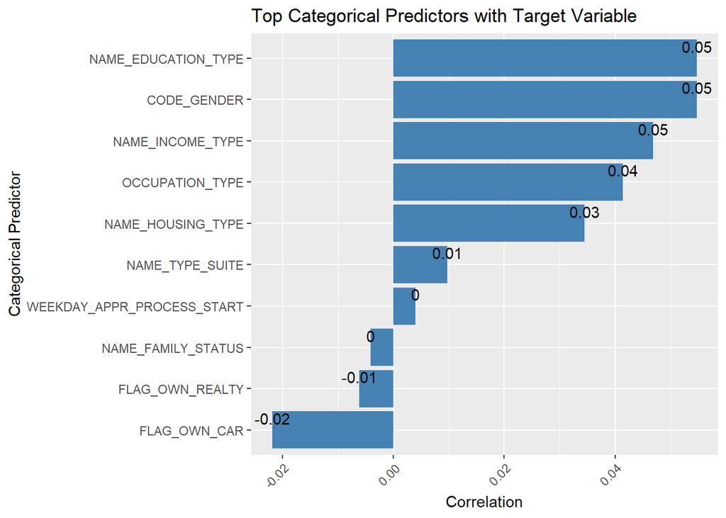

```r
##Visualizing categorical predictors with Target

# Create a bar plot of the top categorical predictors
ggplot(top_categorical_predictors, aes(x = variable, y = correlation, label = round(correlation, 2))) +
  geom_bar(stat = "identity", fill = "steelblue") +
  geom_text(vjust = -0.5) +
  labs(x = "Categorical Predictor", y = "Correlation") +
  ggtitle("Top Categorical Predictors with Target Variable") +
  theme(axis.text.x = element_text(angle = 45, hjust = 1)) +
  coord_flip() +
  scale_fill_manual(values = c("steelblue" = "steelblue"), guide = "none")
```

##NAME_EDUCATION_TYPE, CODE_GENDER, NAME_INCOME_TYPE are the top 3 categorical predictors which has positive correlation wrt TARGET.